# Multicollinearity Essentials and VIF in R

```r
library(MASS)
library(car)
library(dplyr)
library(ggcorrplot)
```

# Collinearity

[Source](http://www.sthda.com/english/articles/39-regression-model-diagnostics/160-multicollinearity-essentials-and-vif-in-r/)

In multiple regression, two or more **predictor variables** might be correlated with each other. This situation is referred as **collinearity**.

There is an extreme situation, called **multicollinearity**, where collinearity exists between three or more variables even if no pair of variables has a particularly high correlation. This means that there is **redundancy** between predictor variables.

In the presence of multicollinearity, **the solution of the regression model becomes unstable**.

# Example

## Correlation analysis

Collinearity issues can be assessed in different ways. The simplest one involves computing the correlation coefficients between variables.

We’ll use the Boston data set in `MASS` package for predicting the median house value (`mdev`) in Boston Suburbs, based on multiple predictor variables. Il dataset Boston contiene tutta una serie di variabili x, noi stiamo cercando di spiegare il prezzo delle case in una certa zona, e poi abbiamo tutte le caratteristiche di quella certa zona.

```r
# Load the data
data("Boston", package = "MASS")
# Split the data into training and test set
# set.seed(123)
# training.samples <- Boston$medv %>%
#   createDataPartition(p = 0.8, list = FALSE)
# train.data  <- Boston[training.samples, ]
# test.data <- Boston[-training.samples, ]
```

We look at the data:

```r
head(Boston)
```

|  | crim | zn | indus | chas | nox | rm | age | dis | rad | tax | ptratio | black | lstat | medv |
| --- | --- | --- | --- | --- | --- | --- | --- | --- | --- | --- | --- | --- | --- | --- |
| 1 | 0.00632 | 18 | 2.31 | 0 | 0.538 | 6.575 | 65.2 | 4.0900 | 1 | 296 | 15.3 | 396.90 | 4.98 | 24.0 |
| 2 | 0.02731 | 0 | 7.07 | 0 | 0.469 | 6.421 | 78.9 | 4.9671 | 2 | 242 | 17.8 | 396.90 | 9.14 | 21.6 |
| 3 | 0.02729 | 0 | 7.07 | 0 | 0.469 | 7.185 | 61.1 | 4.9671 | 2 | 242 | 17.8 | 392.83 | 4.03 | 34.7 |
| 4 | 0.03237 | 0 | 2.18 | 0 | 0.458 | 6.998 | 45.8 | 6.0622 | 3 | 222 | 18.7 | 394.63 | 2.94 | 33.4 |
| 5 | 0.06905 | 0 | 2.18 | 0 | 0.458 | 7.147 | 54.2 | 6.0622 | 3 | 222 | 18.7 | 396.90 | 5.33 | 36.2 |
| 6 | 0.02985 | 0 | 2.18 | 0 | 0.458 | 6.430 | 58.7 | 6.0622 | 3 | 222 | 18.7 | 394.12 | 5.21 | 28.7 |

```r
data(Boston)
```

We select the predictor variables: selezioniamo i potenziali predittori che permettono di prevedere il prezzo delle case, scegliamo le più importanti per spiegare il prezzo delle case.

```r
pred <- dplyr::select(Boston, crim:lstat)
names(pred)
```

```
 [1] "crim"    "zn"      "indus"   "chas"    "nox"     "rm"      "age"     "dis"     "rad"
[10] "tax"     "ptratio" "black"   "lstat"
```

```r
pred
```

|  | crim | zn | indus | chas | nox | rm | age | dis | rad | tax | ptratio | black | lstat |
| --- | --- | --- | --- | --- | --- | --- | --- | --- | --- | --- | --- | --- | --- |
| 1 | 0.00632 | 18.0 | 2.31 | 0 | 0.5380 | 6.575 | 65.2 | 4.0900 | 1 | 296 | 15.3 | 396.90 | 4.98 |
| 2 | 0.02731 | 0.0 | 7.07 | 0 | 0.4690 | 6.421 | 78.9 | 4.9671 | 2 | 242 | 17.8 | 396.90 | 9.14 |
| 3 | 0.02729 | 0.0 | 7.07 | 0 | 0.4690 | 7.185 | 61.1 | 4.9671 | 2 | 242 | 17.8 | 392.83 | 4.03 |
| 4 | 0.03237 | 0.0 | 2.18 | 0 | 0.4580 | 6.998 | 45.8 | 6.0622 | 3 | 222 | 18.7 | 394.63 | 2.94 |
| 5 | 0.06905 | 0.0 | 2.18 | 0 | 0.4580 | 7.147 | 54.2 | 6.0622 | 3 | 222 | 18.7 | 396.90 | 5.33 |
| 6 | 0.02985 | 0.0 | 2.18 | 0 | 0.4580 | 6.430 | 58.7 | 6.0622 | 3 | 222 | 18.7 | 394.12 | 5.21 |
| 7 | 0.08829 | 12.5 | 7.87 | 0 | 0.5240 | 6.012 | 66.6 | 5.5605 | 5 | 311 | 15.2 | 395.60 | 12.43 |
| 8 | 0.14455 | 12.5 | 7.87 | 0 | 0.5240 | 6.172 | 96.1 | 5.9505 | 5 | 311 | 15.2 | 396.90 | 19.15 |
| 9 | 0.21124 | 12.5 | 7.87 | 0 | 0.5240 | 5.631 | 100.0 | 6.0821 | 5 | 311 | 15.2 | 386.63 | 29.93 |
| 10 | 0.17004 | 12.5 | 7.87 | 0 | 0.5240 | 6.004 | 85.9 | 6.5921 | 5 | 311 | 15.2 | 386.71 | 17.10 |

[output cut: 496 more lines]

Now, we can compute a correlation matrix: utilizziamo la funzione cor per creare una matrice di correlazione.

```r
cor.matrix <- cor(pred)
cor.matrix
```

```
               crim          zn       indus         chas         nox          rm         age
crim     1.00000000 -0.20046922  0.40658341 -0.055891582  0.42097171 -0.21924670  0.35273425
zn      -0.20046922  1.00000000 -0.53382819 -0.042696719 -0.51660371  0.31199059 -0.56953734
indus    0.40658341 -0.53382819  1.00000000  0.062938027  0.76365145 -0.39167585  0.64477851
chas    -0.05589158 -0.04269672  0.06293803  1.000000000  0.09120281  0.09125123  0.08651777
nox      0.42097171 -0.51660371  0.76365145  0.091202807  1.00000000 -0.30218819  0.73147010
rm      -0.21924670  0.31199059 -0.39167585  0.091251225 -0.30218819  1.00000000 -0.24026493
age      0.35273425 -0.56953734  0.64477851  0.086517774  0.73147010 -0.24026493  1.00000000
dis     -0.37967009  0.66440822 -0.70802699 -0.099175780 -0.76923011  0.20524621 -0.74788054
rad      0.62550515 -0.31194783  0.59512927 -0.007368241  0.61144056 -0.20984667  0.45602245
tax      0.58276431 -0.31456332  0.72076018 -0.035586518  0.66802320 -0.29204783  0.50645559
ptratio  0.28994558 -0.39167855  0.38324756 -0.121515174  0.18893268 -0.35550149  0.26151501
black   -0.38506394  0.17552032 -0.35697654  0.048788485 -0.38005064  0.12806864 -0.27353398
lstat    0.45562148 -0.41299457  0.60379972 -0.053929298  0.59087892 -0.61380827  0.60233853
                dis          rad         tax    ptratio       black      lstat
crim    -0.37967009  0.625505145  0.58276431  0.2899456 -0.38506394  0.4556215
zn       0.66440822 -0.311947826 -0.31456332 -0.3916785  0.17552032 -0.4129946
indus   -0.70802699  0.595129275  0.72076018  0.3832476 -0.35697654  0.6037997
chas    -0.09917578 -0.007368241 -0.03558652 -0.1215152  0.04878848 -0.0539293
nox     -0.76923011  0.611440563  0.66802320  0.1889327 -0.38005064  0.5908789
rm       0.20524621 -0.209846668 -0.29204783 -0.3555015  0.12806864 -0.6138083
age     -0.74788054  0.456022452  0.50645559  0.2615150 -0.27353398  0.6023385
dis      1.00000000 -0.494587930 -0.53443158 -0.2324705  0.29151167 -0.4969958
rad     -0.49458793  1.000000000  0.91022819  0.4647412 -0.44441282  0.4886763
tax     -0.53443158  0.910228189  1.00000000  0.4608530 -0.44180801  0.5439934
ptratio -0.23247054  0.464741179  0.46085304  1.0000000 -0.17738330  0.3740443
black    0.29151167 -0.444412816 -0.44180801 -0.1773833  1.00000000 -0.3660869
lstat   -0.49699583  0.488676335  0.54399341  0.3740443 -0.36608690  1.0000000
```

ad esempio, tra tax e indus c’è un coefficiente di 0.7 abbastanza alto che già ci dice qualcosa. And we can visualize it: se il cor>0.7, eliminiamo una variabile.Per scegliere quale, consideriamo il significato della variabile, la facilità di reperibilità dei dati per quella variabile, e se non riuscissimo a scartare neanche così facciamo un modello,e lasciamo alla matematica decidere il modello migliore che “fitta” meglio, in base all’AIC appunto.

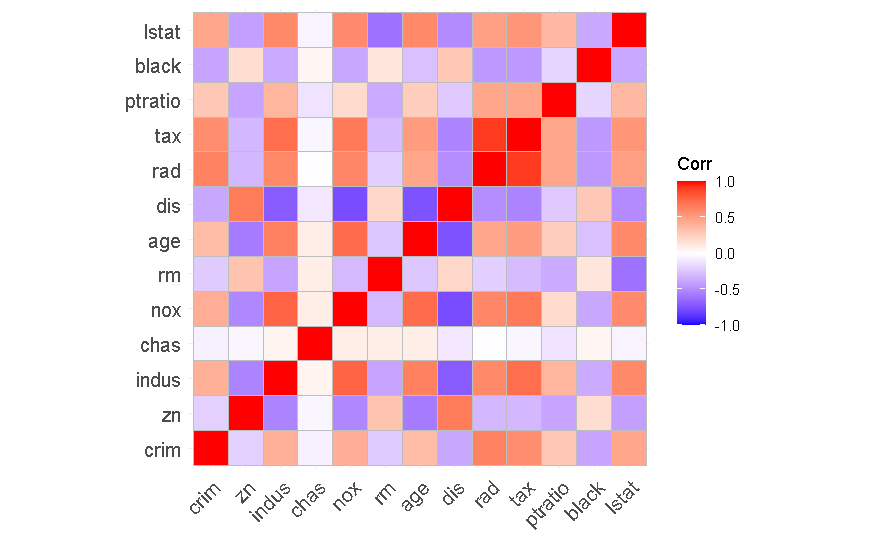

```r
ggcorrplot(cor.matrix)
```

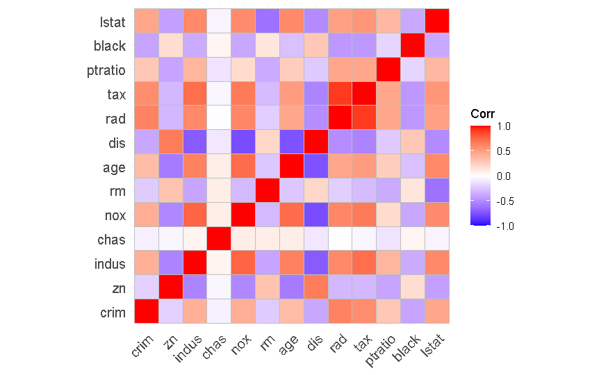

```r
ggcorrplot(cor(pred))
```

Just a different visualization:

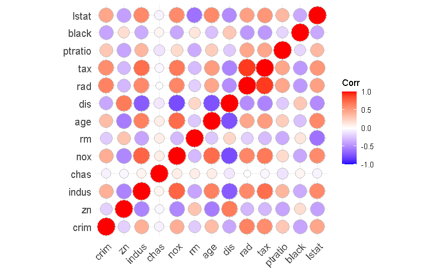

```r
ggcorrplot(cor.matrix, method = "circle")
```

We can add labels, but it is still difficult detecting relevant correlations:

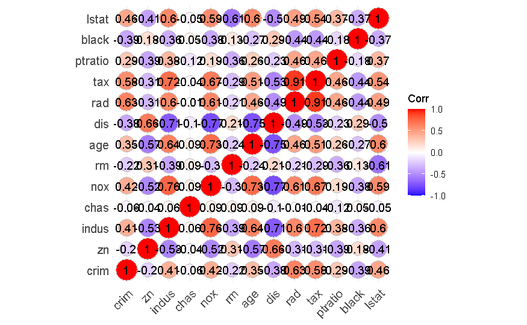

```r
ggcorrplot(cor.matrix, method = "circle", lab=TRUE)
```

possiamo chiedere a R di andare a identificare nella nostra matrice dove ci sono i problemi di correlazione. Prendiamo in valore assoluto la matrice precedente, perchè appunto non importa il segno, e andiamo a dirgli di metterci un TRuE o FALSE. We set a threshold to identify relevant correlations:

```r
p.mat <- (abs(cor.matrix) > 0.7)
p.mat
```

```
         crim    zn indus  chas   nox    rm   age   dis   rad   tax ptratio black lstat
crim     TRUE FALSE FALSE FALSE FALSE FALSE FALSE FALSE FALSE FALSE   FALSE FALSE FALSE
zn      FALSE  TRUE FALSE FALSE FALSE FALSE FALSE FALSE FALSE FALSE   FALSE FALSE FALSE
indus   FALSE FALSE  TRUE FALSE  TRUE FALSE FALSE  TRUE FALSE  TRUE   FALSE FALSE FALSE
chas    FALSE FALSE FALSE  TRUE FALSE FALSE FALSE FALSE FALSE FALSE   FALSE FALSE FALSE
nox     FALSE FALSE  TRUE FALSE  TRUE FALSE  TRUE  TRUE FALSE FALSE   FALSE FALSE FALSE
rm      FALSE FALSE FALSE FALSE FALSE  TRUE FALSE FALSE FALSE FALSE   FALSE FALSE FALSE
age     FALSE FALSE FALSE FALSE  TRUE FALSE  TRUE  TRUE FALSE FALSE   FALSE FALSE FALSE
dis     FALSE FALSE  TRUE FALSE  TRUE FALSE  TRUE  TRUE FALSE FALSE   FALSE FALSE FALSE
rad     FALSE FALSE FALSE FALSE FALSE FALSE FALSE FALSE  TRUE  TRUE   FALSE FALSE FALSE
tax     FALSE FALSE  TRUE FALSE FALSE FALSE FALSE FALSE  TRUE  TRUE   FALSE FALSE FALSE
ptratio FALSE FALSE FALSE FALSE FALSE FALSE FALSE FALSE FALSE FALSE    TRUE FALSE FALSE
black   FALSE FALSE FALSE FALSE FALSE FALSE FALSE FALSE FALSE FALSE   FALSE  TRUE FALSE
lstat   FALSE FALSE FALSE FALSE FALSE FALSE FALSE FALSE FALSE FALSE   FALSE FALSE  TRUE
```

ora, R ci mette una crocetta su quelle coppie di variabili che sono correlate tra loro . Ci sono 7 coppie di variabili correlate.

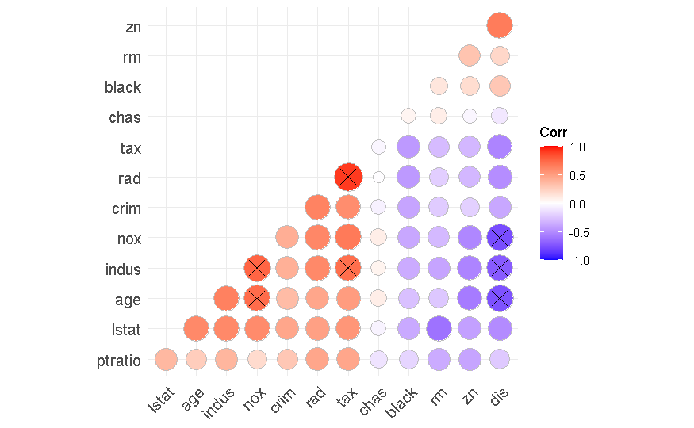

```r
# Argument p.mat
# Barring the significant coefficients
ggcorrplot(cor.matrix,
  hc.order = TRUE, method = "circle", #metti in ordine i valori
  type = "lower", p.mat = p.mat #stampami solo la parte inferiore della matrice
) #perchè è una matrice speculare.
```

Indus ha ben tre problemi di correlazione, quindi posso agire per eliminarlo, perchè è molto correlato. Posso procedere tenendo quelle che non sono correlate insieme a quelle da tenere con attenzione.Di solito per ogni parametro stimato dobbiamo avere almeno 10-15 righe nel dataset. questo era il primo metodo “a monte”…..poi possiamo fittare un modello lineare che consideri tutte le variabili e mi dia il suo summary. When faced to multicollinearity, the concerned variables should be removed, since the presence of multicollinearity implies that the information that this variable provides about the response is redundant in the presence of the other variables (James et al. 2014,P. Bruce and Bruce (2017)).

## Variance Inflation Factor

For a given predictor, multicollinearity can also be assessed by computing a score called the variance inflation factor (or **VIF**), which **measures how much the variance of a regression coefficient is inflated due to multicollinearity in the model**.

The smallest possible value of VIF is **one (absence of multicollinearity)**. As a rule of thumb, **a VIF value that exceeds 5 or 10 indicates a problematic amount of collinearity (James et al. 2014)**.

The following regression model include all predictor variables:

```r
# Build the model
model1 <- lm(medv ~ ., data = Boston)
summary(model1)
```

```
Call:
lm(formula = medv ~ ., data = Boston)

Residuals:
    Min      1Q  Median      3Q     Max
-15.595  -2.730  -0.518   1.777  26.199

Coefficients:
              Estimate Std. Error t value Pr(>|t|)
(Intercept)  3.646e+01  5.103e+00   7.144 3.28e-12 ***
crim        -1.080e-01  3.286e-02  -3.287 0.001087 **
zn           4.642e-02  1.373e-02   3.382 0.000778 ***
indus        2.056e-02  6.150e-02   0.334 0.738288
chas         2.687e+00  8.616e-01   3.118 0.001925 **
nox         -1.777e+01  3.820e+00  -4.651 4.25e-06 ***
rm           3.810e+00  4.179e-01   9.116  < 2e-16 ***
age          6.922e-04  1.321e-02   0.052 0.958229
dis         -1.476e+00  1.995e-01  -7.398 6.01e-13 ***
rad          3.060e-01  6.635e-02   4.613 5.07e-06 ***
tax         -1.233e-02  3.760e-03  -3.280 0.001112 **
ptratio     -9.527e-01  1.308e-01  -7.283 1.31e-12 ***
black        9.312e-03  2.686e-03   3.467 0.000573 ***
lstat       -5.248e-01  5.072e-02 -10.347  < 2e-16 ***
---
Signif. codes:  0 ‘***’ 0.001 ‘**’ 0.01 ‘*’ 0.05 ‘.’ 0.1 ‘ ’ 1

Residual standard error: 4.745 on 492 degrees of freedom
Multiple R-squared:  0.7406,    Adjusted R-squared:  0.7338
F-statistic: 108.1 on 13 and 492 DF,  p-value: < 2.2e-16
```

non possiamo fidarci di questo output perchè l’errore standard di 3.8 “non ci possiamo credere” (è un esempio) perchè la multicollinearità fa cambiare le stime , perchè prima dall’analisi precedente avevamo ottenuto alcune correlazioni>0.7.

The R function `vif()`, (variance inflation factor)in the `car` package, can be used to detect multicollinearity in a regression model:

```r
vif(model1)
```

```
    crim       zn    indus     chas      nox       rm      age      dis      rad      tax
1.792192 2.298758 3.991596 1.073995 4.393720 1.933744 3.100826 3.955945 7.484496 9.008554
 ptratio    black    lstat
1.799084 1.348521 2.941491
```

Generalmente se il VIF è maggiore di 5/10 ci indica che quelle variabili stanno soffrendo la collinearità e andrebbero eliminate dal dataset. In this case, we can see that the `rad` and `tax` predictors have high VIF values - compare with the results of the correlation analysis above!!

# Exercise

Consider a dataset from air pollution studies. How is sulphur dioxide concentration (`Pollution`) related to other variables in the dataset? Are there any problems of collinearity?

```r
pollution <- read.table("data/sulphur.dioxide.txt", header=TRUE)
View(pollution)
```

In multiple regression, it is always a good idea to use pairs to look at all the correlations:

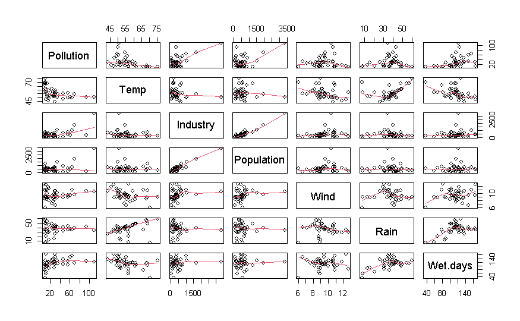

```r
pairs(pollution,panel=panel.smooth)
```

generiamo degli “scatterplot a coppie per la nostra matrice di correlazione” Check for relevant correlations and visualize them. Compute the variance inflation factor and update the model accordingly.

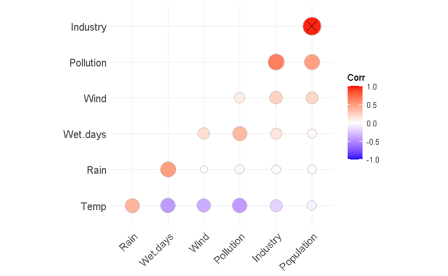

```r
cor.matrix <- cor(pollution)
# cor.matrix
p.mat <- (abs(cor.matrix) > 0.7)
# p.mat
ggcorrplot(cor.matrix,
  hc.order = TRUE, method = "circle",
  type = "lower", p.mat = p.mat
)
```

su industria e popolazione c’è un caso effettivamente problematico.

```r
# Build the model
model1 <- lm(Pollution ~ ., data = pollution)
summary(model1)
```

```
Call:
lm(formula = Pollution ~ ., data = pollution)

Residuals:
    Min      1Q  Median      3Q     Max
-23.159  -8.522  -1.147   5.823  48.586

Coefficients:
             Estimate Std. Error t value Pr(>|t|)
(Intercept) 111.59357   47.11131   2.369 0.023673 *
Temp         -1.26510    0.61796  -2.047 0.048427 *
Industry      0.06542    0.01567   4.175 0.000196 ***
Population   -0.03975    0.01506  -2.640 0.012430 *
Wind         -3.17961    1.81397  -1.753 0.088643 .
Rain          0.50507    0.36118   1.398 0.171054
Wet.days     -0.04911    0.16123  -0.305 0.762554
---
Signif. codes:  0 ‘***’ 0.001 ‘**’ 0.01 ‘*’ 0.05 ‘.’ 0.1 ‘ ’ 1

Residual standard error: 14.57 on 34 degrees of freedom
Multiple R-squared:  0.6723,    Adjusted R-squared:  0.6145
F-statistic: 11.63 on 6 and 34 DF,  p-value: 4.721e-07
```

```r
vif(model1)
```

```
      Temp   Industry Population       Wind       Rain   Wet.days
  3.757129  14.668159  14.319610   1.255888   3.404681   3.439836
```

```r
model1 <- lm(Pollution ~ Temp + Industry + Wind + Rain + Wet.days, data = pollution)
summary(model1)
```

```
Call:
lm(formula = Pollution ~ Temp + Industry + Wind + Rain + Wet.days,
    data = pollution)

Residuals:
    Min      1Q  Median      3Q     Max
-20.483  -8.785  -3.149   7.120  58.013

Coefficients:
              Estimate Std. Error t value Pr(>|t|)
(Intercept) 135.825337  49.993685   2.717  0.01017 *
Temp         -1.771656   0.635532  -2.788  0.00852 **
Industry      0.025606   0.004597   5.571 2.84e-06 ***
Wind         -3.750067   1.948589  -1.925  0.06245 .
Rain          0.622758   0.387777   1.606  0.11727
Wet.days     -0.055288   0.174421  -0.317  0.75314
---
Signif. codes:  0 ‘***’ 0.001 ‘**’ 0.01 ‘*’ 0.05 ‘.’ 0.1 ‘ ’ 1

Residual standard error: 15.77 on 35 degrees of freedom
Multiple R-squared:  0.6052,    Adjusted R-squared:  0.5488
F-statistic: 10.73 on 5 and 35 DF,  p-value: 2.621e-06
```

togliendo la variabile population si è abbassato drasticamente l’errore standard su Industry. solo dopo aver calcolato il VIF ci concentriamo sull’output. Solo alla fine, ed escludendo ogni ipotesi di collinearità si valutano gli AIC tra i modelli.